# Objective

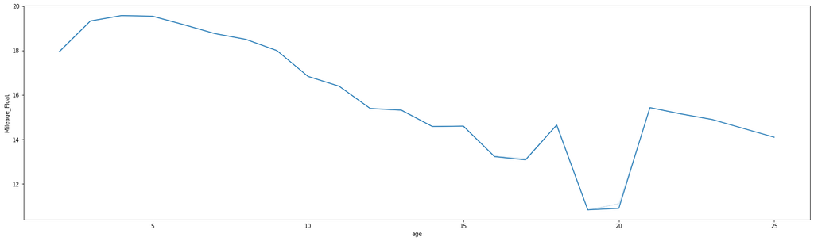

```python
plt.figure(figsize=(25,7))
sns.lineplot(y='Mileage_Float', x='age',palette = 'winter',ci=0,
             data=df);
```

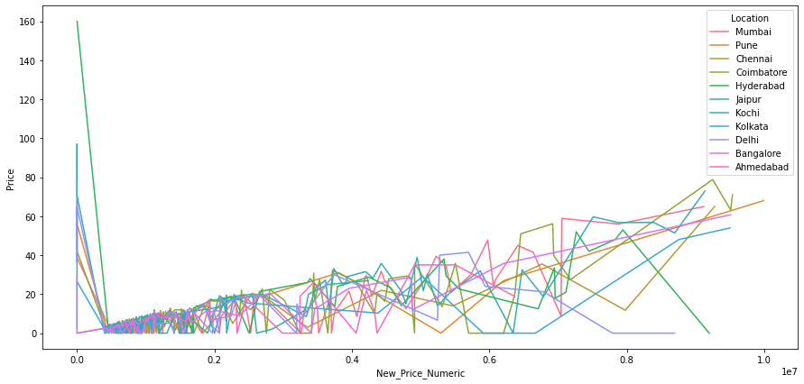

```python
plt.figure(figsize=(15,7))
sns.lineplot(y='Price', x='New_Price_Numeric',hue='Location',ci=0,
             data=df);
```

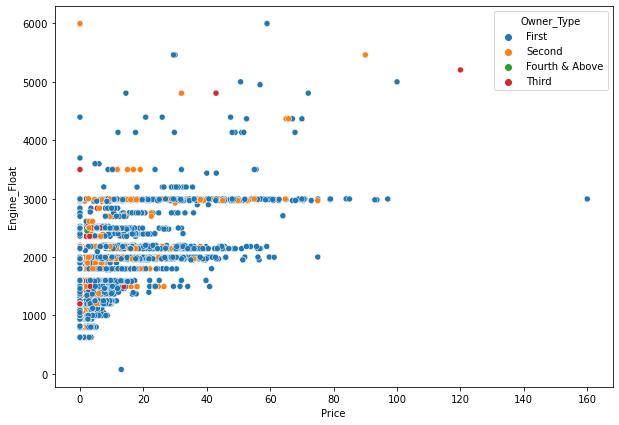

```python
plt.figure(figsize=(10,7));
sns.scatterplot(x="Price", y="Engine_Float",hue="Owner_Type",data=df);
```

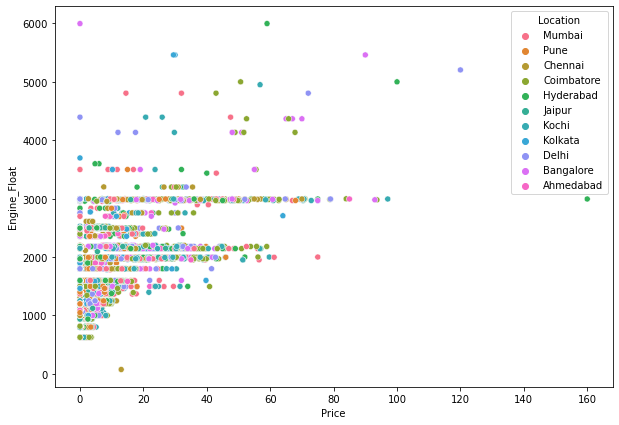

```python
plt.figure(figsize=(10,7));
sns.scatterplot(x="Price", y="Engine_Float",hue="Location",data=df);
```

```python
plt.show()
```

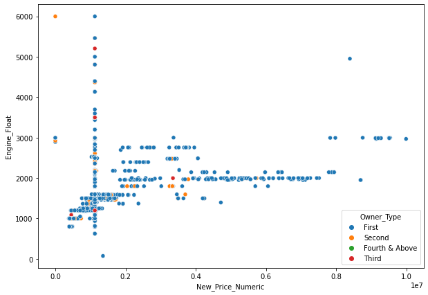

```python
plt.figure(figsize=(10,7));
sns.scatterplot(x="New_Price_Numeric", y="Engine_Float",hue="Owner_Type",data=df);
```

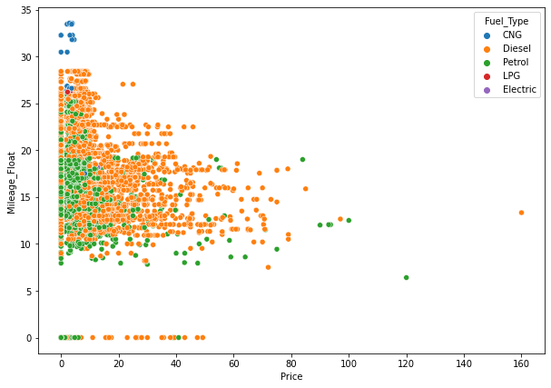

```python
plt.figure(figsize=(10,7));
sns.scatterplot(x="Price", y="Mileage_Float",hue="Fuel_Type",data=df);
```

1.Diesel cars give better mileage.  
2.Cng fuel type of cars can also give high mileage but less price.

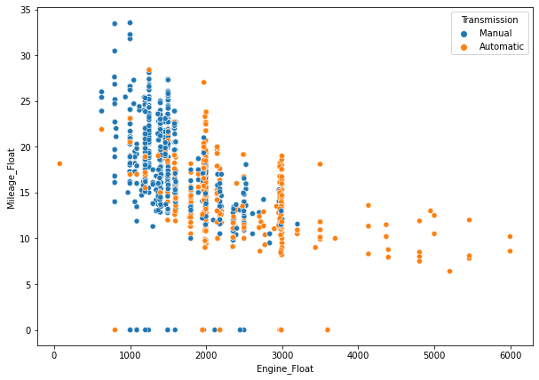

```python
plt.figure(figsize=(10,7))
sns.scatterplot(x='Engine_Float', y='Mileage_Float',hue='Transmission',ci=0,
             data=df);
```

1.Manual cars give high mileage compare to automatic cars.

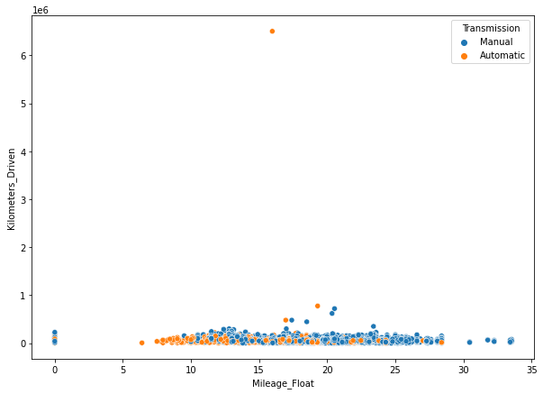

```python
plt.figure(figsize=(10,7))
sns.scatterplot(x='Mileage_Float', y='Kilometers_Driven',hue='Transmission',ci=0,
             data=df);
```

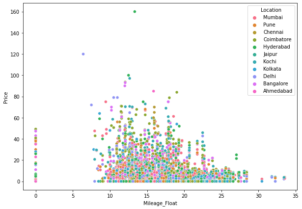

```python
plt.figure(figsize=(10,7))
sns.scatterplot(x='Mileage_Float', y='Price',hue='Location',ci=0,
             data=df);
```

1.Mileage distributed from 10 to 20.

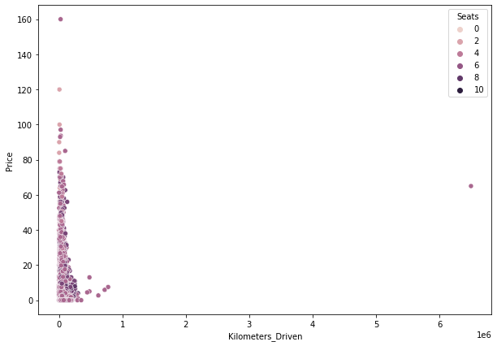

```python
plt.figure(figsize=(10,7))
sns.scatterplot(x='Kilometers_Driven', y='Price',hue='Seats',ci=0,
             data=df);
```

```python
le_brand = preprocessing.LabelEncoder()
le_brand.fit(df['brand'])
df['brand'] = le_brand.transform(df['brand'])
```

# log transformation for skewed variables

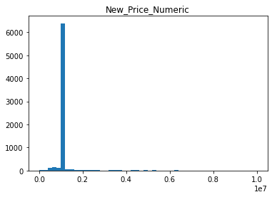

```
0
```

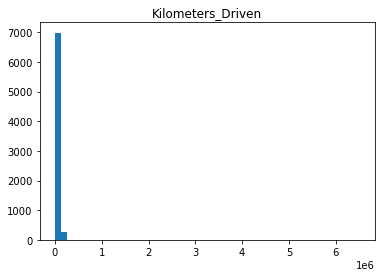

```
0
```

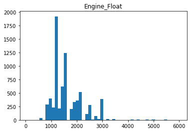

```
0
```

```python
cols_log = ['New_Price_Numeric','Kilometers_Driven','Engine_Float']
for colname in cols_log:
    plt.hist(df[colname], bins=50)
    plt.title(colname)
    plt.show()
    print(np.sum(df[colname] <= 0))
```

```python
for colname in cols_log:
    df[colname+'_log'] = np.log(df[colname] + 1)
df.drop(cols_log, axis=1, inplace=True)
```

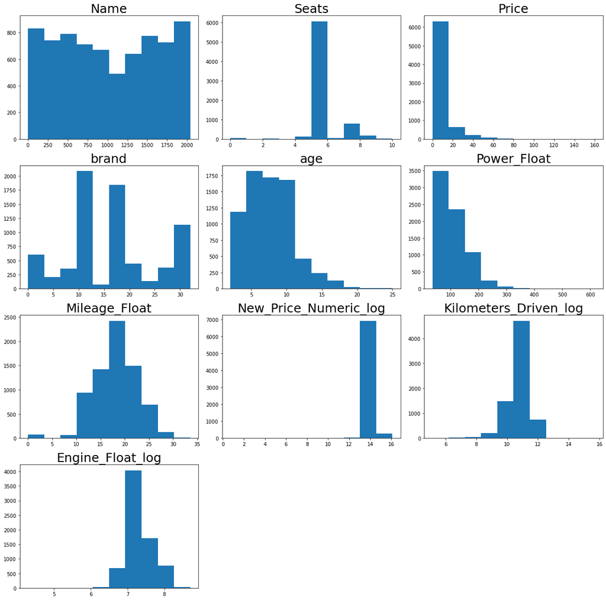

```python
from scipy.stats import norm
all_col = df.select_dtypes(include=np.number).columns.tolist()
all_col.remove('Year')
plt.figure(figsize=(17,75))

for i in range(len(all_col)):
    plt.subplot(18,3,i+1)
    plt.hist(df[all_col[i]])
    #sns.displot(df[all_col[i]], kde=True)
    plt.tight_layout()
    plt.title(all_col[i],fontsize=25)


plt.show()
```

```python
df.info()
```

```
<class 'pandas.core.frame.DataFrame'>
Int64Index: 7253 entries, 0 to 7252
Data columns (total 15 columns):
 #   Column                 Non-Null Count  Dtype
---  ------                 --------------  -----
 0   Name                   7253 non-null   int64
 1   Location               7253 non-null   object
 2   Year                   7253 non-null   int64
 3   Fuel_Type              7253 non-null   object
 4   Transmission           7253 non-null   object
 5   Owner_Type             7253 non-null   object
 6   Seats                  7253 non-null   float64
 7   Price                  7253 non-null   float64
 8   brand                  7253 non-null   int64
 9   age                    7253 non-null   int64
 10  Power_Float            7253 non-null   float64
 11  Mileage_Float          7253 non-null   float64
 12  New_Price_Numeric_log  7253 non-null   float64
 13  Kilometers_Driven_log  7253 non-null   float64
 14  Engine_Float_log       7253 non-null   float64
dtypes: float64(7), int64(4), object(4)
memory usage: 1.2+ MB
```

```python
df
```

| S.No. | Name | Location | Year | Fuel_Type | Transmission | Owner_Type | Seats | Price | brand | age | Power_Float | Mileage_Float | New_Price_Numeric_log | Kilometers_Driven_log | Engine_Float_log |
| --- | --- | --- | --- | --- | --- | --- | --- | --- | --- | --- | --- | --- | --- | --- | --- |
| 0 | 1797 | Mumbai | 2010 | CNG | Manual | First | 5.0 | 1.75 | 19 | 11 | 58.16 | 26.60 | 13.935071 | 11.184435 | 6.906755 |
| 1 | 498 | Pune | 2015 | Diesel | Manual | First | 5.0 | 12.50 | 11 | 6 | 126.20 | 19.67 | 13.935071 | 10.621352 | 7.367077 |
| 2 | 993 | Chennai | 2011 | Petrol | Manual | First | 5.0 | 4.50 | 10 | 10 | 88.70 | 18.20 | 13.665851 | 10.736418 | 7.090077 |
| 3 | 676 | Chennai | 2012 | Diesel | Manual | First | 7.0 | 6.00 | 19 | 9 | 88.76 | 20.77 | 13.935071 | 11.373675 | 7.130099 |
| 4 | 105 | Coimbatore | 2013 | Diesel | Automatic | Second | 5.0 | 17.74 | 1 | 8 | 140.80 | 15.20 | 13.935071 | 10.613271 | 7.585281 |
| ... | ... | ... | ... | ... | ... | ... | ... | ... | ... | ... | ... | ... | ... | ... | ... |
| 7248 | 1701 | Hyderabad | 2011 | Diesel | Manual | First | 5.0 | 0.00 | 31 | 10 | 103.60 | 20.54 | 13.935071 | 11.401010 | 7.377134 |
| 7249 | 1252 | Mumbai | 2015 | Petrol | Automatic | First | 5.0 | 0.00 | 31 | 6 | 103.60 | 17.21 | 13.935071 | 10.985310 | 7.088409 |
| 7250 | 1101 | Kolkata | 2012 | Diesel | Manual | First | 5.0 | 0.00 | 23 | 9 | 63.10 | 23.08 | 13.935071 | 10.239996 | 7.287561 |
| 7251 | 1252 | Pune | 2013 | Petrol | Automatic | Third | 5.0 | 0.00 | 31 | 8 | 103.60 | 17.20 | 13.935071 | 10.864044 | 7.088409 |
| 7252 | 551 | Kochi | 2014 | Diesel | Automatic | First | 5.0 | 0.00 | 20 | 7 | 170.00 | 10.00 | 13.935071 | 11.190569 | 7.672758 |

7253 rows × 15 columns

# Outlier treatment

```python
def treat_outliers(df,col):
    Q1=df[col].quantile(0.25)
    Q3=df[col].quantile(0.75)
    IQR=Q3-Q1
    Lower_Whisker = Q1 - 1.5*IQR
    Upper_Whisker = Q3 + 1.5*IQR
    df[col] = np.clip(df[col], Lower_Whisker, Upper_Whisker)
    return df
```

```python
def treat_outliers_all(df, col_list):
    for c in col_list:
        df = treat_outliers(df,c)
    return df
```

```python
num_col = df.select_dtypes(include=np.float).columns.tolist()
df = treat_outliers_all(df,num_col)
```

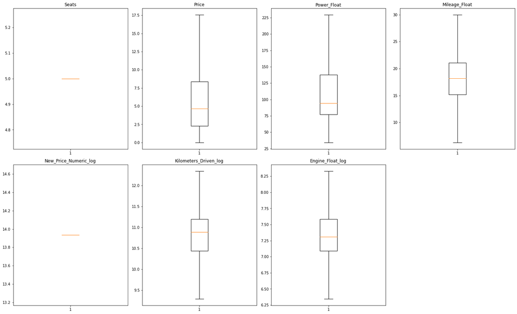

```python
plt.figure(figsize=(20,30))

for i, variable in enumerate(num_col):
                     plt.subplot(5,4,i+1)
                     plt.boxplot(df[variable],whis=1.5)
                     plt.tight_layout()
                     plt.title(variable)

plt.show()
```

```python
df.shape
```

```
(7253, 15)
```

```python
df
```

| S.No. | Name | Location | Year | Fuel_Type | Transmission | Owner_Type | Seats | Price | brand | age | Power_Float | Mileage_Float | New_Price_Numeric_log | Kilometers_Driven_log | Engine_Float_log |
| --- | --- | --- | --- | --- | --- | --- | --- | --- | --- | --- | --- | --- | --- | --- | --- |
| 0 | 1797 | Mumbai | 2010 | CNG | Manual | First | 5.0 | 1.750 | 19 | 11 | 58.16 | 26.60 | 13.935071 | 11.184435 | 6.906755 |
| 1 | 498 | Pune | 2015 | Diesel | Manual | First | 5.0 | 12.500 | 11 | 6 | 126.20 | 19.67 | 13.935071 | 10.621352 | 7.367077 |
| 2 | 993 | Chennai | 2011 | Petrol | Manual | First | 5.0 | 4.500 | 10 | 10 | 88.70 | 18.20 | 13.935071 | 10.736418 | 7.090077 |
| 3 | 676 | Chennai | 2012 | Diesel | Manual | First | 5.0 | 6.000 | 19 | 9 | 88.76 | 20.77 | 13.935071 | 11.373675 | 7.130099 |
| 4 | 105 | Coimbatore | 2013 | Diesel | Automatic | Second | 5.0 | 17.565 | 1 | 8 | 140.80 | 15.20 | 13.935071 | 10.613271 | 7.585281 |
| ... | ... | ... | ... | ... | ... | ... | ... | ... | ... | ... | ... | ... | ... | ... | ... |
| 7248 | 1701 | Hyderabad | 2011 | Diesel | Manual | First | 5.0 | 0.000 | 31 | 10 | 103.60 | 20.54 | 13.935071 | 11.401010 | 7.377134 |
| 7249 | 1252 | Mumbai | 2015 | Petrol | Automatic | First | 5.0 | 0.000 | 31 | 6 | 103.60 | 17.21 | 13.935071 | 10.985310 | 7.088409 |
| 7250 | 1101 | Kolkata | 2012 | Diesel | Manual | First | 5.0 | 0.000 | 23 | 9 | 63.10 | 23.08 | 13.935071 | 10.239996 | 7.287561 |
| 7251 | 1252 | Pune | 2013 | Petrol | Automatic | Third | 5.0 | 0.000 | 31 | 8 | 103.60 | 17.20 | 13.935071 | 10.864044 | 7.088409 |
| 7252 | 551 | Kochi | 2014 | Diesel | Automatic | First | 5.0 | 0.000 | 20 | 7 | 170.00 | 10.00 | 13.935071 | 11.190569 | 7.672758 |

7253 rows × 15 columns

```python
df2=df.copy()
```

```python
df2
```

| S.No. | Name | Location | Year | Fuel_Type | Transmission | Owner_Type | Seats | Price | brand | age | Power_Float | Mileage_Float | New_Price_Numeric_log | Kilometers_Driven_log | Engine_Float_log |
| --- | --- | --- | --- | --- | --- | --- | --- | --- | --- | --- | --- | --- | --- | --- | --- |
| 0 | 1797 | Mumbai | 2010 | CNG | Manual | First | 5.0 | 1.750 | 19 | 11 | 58.16 | 26.60 | 13.935071 | 11.184435 | 6.906755 |
| 1 | 498 | Pune | 2015 | Diesel | Manual | First | 5.0 | 12.500 | 11 | 6 | 126.20 | 19.67 | 13.935071 | 10.621352 | 7.367077 |
| 2 | 993 | Chennai | 2011 | Petrol | Manual | First | 5.0 | 4.500 | 10 | 10 | 88.70 | 18.20 | 13.935071 | 10.736418 | 7.090077 |
| 3 | 676 | Chennai | 2012 | Diesel | Manual | First | 5.0 | 6.000 | 19 | 9 | 88.76 | 20.77 | 13.935071 | 11.373675 | 7.130099 |
| 4 | 105 | Coimbatore | 2013 | Diesel | Automatic | Second | 5.0 | 17.565 | 1 | 8 | 140.80 | 15.20 | 13.935071 | 10.613271 | 7.585281 |
| ... | ... | ... | ... | ... | ... | ... | ... | ... | ... | ... | ... | ... | ... | ... | ... |
| 7248 | 1701 | Hyderabad | 2011 | Diesel | Manual | First | 5.0 | 0.000 | 31 | 10 | 103.60 | 20.54 | 13.935071 | 11.401010 | 7.377134 |
| 7249 | 1252 | Mumbai | 2015 | Petrol | Automatic | First | 5.0 | 0.000 | 31 | 6 | 103.60 | 17.21 | 13.935071 | 10.985310 | 7.088409 |
| 7250 | 1101 | Kolkata | 2012 | Diesel | Manual | First | 5.0 | 0.000 | 23 | 9 | 63.10 | 23.08 | 13.935071 | 10.239996 | 7.287561 |
| 7251 | 1252 | Pune | 2013 | Petrol | Automatic | Third | 5.0 | 0.000 | 31 | 8 | 103.60 | 17.20 | 13.935071 | 10.864044 | 7.088409 |
| 7252 | 551 | Kochi | 2014 | Diesel | Automatic | First | 5.0 | 0.000 | 20 | 7 | 170.00 | 10.00 | 13.935071 | 11.190569 | 7.672758 |

7253 rows × 15 columns

```python
df2.info()
```

```
<class 'pandas.core.frame.DataFrame'>
Int64Index: 7253 entries, 0 to 7252
Data columns (total 15 columns):
 #   Column                 Non-Null Count  Dtype
---  ------                 --------------  -----
 0   Name                   7253 non-null   int64
 1   Location               7253 non-null   object
 2   Year                   7253 non-null   int64
 3   Fuel_Type              7253 non-null   object
 4   Transmission           7253 non-null   object
 5   Owner_Type             7253 non-null   object
 6   Seats                  7253 non-null   float64
 7   Price                  7253 non-null   float64
 8   brand                  7253 non-null   int64
 9   age                    7253 non-null   int64
 10  Power_Float            7253 non-null   float64
 11  Mileage_Float          7253 non-null   float64
 12  New_Price_Numeric_log  7253 non-null   float64
 13  Kilometers_Driven_log  7253 non-null   float64
 14  Engine_Float_log       7253 non-null   float64
dtypes: float64(7), int64(4), object(4)
memory usage: 1.2+ MB
```

# Create dummies

```python
df2 = pd.get_dummies(df2, columns=['Location'])
df2 = pd.get_dummies(df2, columns=['Transmission'])
df2 = pd.get_dummies(df2, columns=['Owner_Type'])
df2 = pd.get_dummies(df2, columns=['Fuel_Type'])
#df2 = pd.get_dummies(df2,columns=['brand'])
df2.head()
```

| S.No. | Name | Year | Seats | Price | brand | age | Power_Float | Mileage_Float | New_Price_Numeric_log | Kilometers_Driven_log | ... | Transmission_Manual | Owner_Type_First | Owner_Type_Fourth & Above | Owner_Type_Second | Owner_Type_Third | Fuel_Type_CNG | Fuel_Type_Diesel | Fuel_Type_Electric | Fuel_Type_LPG | Fuel_Type_Petrol |
| --- | --- | --- | --- | --- | --- | --- | --- | --- | --- | --- | --- | --- | --- | --- | --- | --- | --- | --- | --- | --- | --- |
| 0 | 1797 | 2010 | 5.0 | 1.750 | 19 | 11 | 58.16 | 26.60 | 13.935071 | 11.184435 | ... | 1 | 1 | 0 | 0 | 0 | 1 | 0 | 0 | 0 | 0 |
| 1 | 498 | 2015 | 5.0 | 12.500 | 11 | 6 | 126.20 | 19.67 | 13.935071 | 10.621352 | ... | 1 | 1 | 0 | 0 | 0 | 0 | 1 | 0 | 0 | 0 |
| 2 | 993 | 2011 | 5.0 | 4.500 | 10 | 10 | 88.70 | 18.20 | 13.935071 | 10.736418 | ... | 1 | 1 | 0 | 0 | 0 | 0 | 0 | 0 | 0 | 1 |
| 3 | 676 | 2012 | 5.0 | 6.000 | 19 | 9 | 88.76 | 20.77 | 13.935071 | 11.373675 | ... | 1 | 1 | 0 | 0 | 0 | 0 | 1 | 0 | 0 | 0 |
| 4 | 105 | 2013 | 5.0 | 17.565 | 1 | 8 | 140.80 | 15.20 | 13.935071 | 10.613271 | ... | 0 | 0 | 0 | 1 | 0 | 0 | 1 | 0 | 0 | 0 |

5 rows × 33 columns

```python
df.Year.unique
```

```
<bound method Series.unique of S.No.
0       2010
1       2015
2       2011
3       2012
4       2013
        ...
7248    2011
7249    2015
7250    2012
7251    2013
7252    2014
Name: Year, Length: 7253, dtype: int64>
```

```python
df2.head(20)
```

| S.No. | Name | Year | Seats | Price | brand | age | Power_Float | Mileage_Float | New_Price_Numeric_log | Kilometers_Driven_log | ... | Transmission_Manual | Owner_Type_First | Owner_Type_Fourth & Above | Owner_Type_Second | Owner_Type_Third | Fuel_Type_CNG | Fuel_Type_Diesel | Fuel_Type_Electric | Fuel_Type_LPG | Fuel_Type_Petrol |
| --- | --- | --- | --- | --- | --- | --- | --- | --- | --- | --- | --- | --- | --- | --- | --- | --- | --- | --- | --- | --- | --- |
| 0 | 1797 | 2010 | 5.0 | 1.750 | 19 | 11 | 58.16 | 26.600 | 13.935071 | 11.184435 | ... | 1 | 1 | 0 | 0 | 0 | 1 | 0 | 0 | 0 | 0 |
| 1 | 498 | 2015 | 5.0 | 12.500 | 11 | 6 | 126.20 | 19.670 | 13.935071 | 10.621352 | ... | 1 | 1 | 0 | 0 | 0 | 0 | 1 | 0 | 0 | 0 |
| 2 | 993 | 2011 | 5.0 | 4.500 | 10 | 10 | 88.70 | 18.200 | 13.935071 | 10.736418 | ... | 1 | 1 | 0 | 0 | 0 | 0 | 0 | 0 | 0 | 1 |
| 3 | 676 | 2012 | 5.0 | 6.000 | 19 | 9 | 88.76 | 20.770 | 13.935071 | 11.373675 | ... | 1 | 1 | 0 | 0 | 0 | 0 | 1 | 0 | 0 | 0 |
| 4 | 105 | 2013 | 5.0 | 17.565 | 1 | 8 | 140.80 | 15.200 | 13.935071 | 10.613271 | ... | 0 | 0 | 0 | 1 | 0 | 0 | 1 | 0 | 0 | 0 |
| 5 | 591 | 2012 | 5.0 | 2.350 | 11 | 9 | 55.20 | 21.100 | 13.935071 | 11.225257 | ... | 1 | 1 | 0 | 0 | 0 | 0 | 0 | 0 | 1 | 0 |
| 6 | 1101 | 2013 | 5.0 | 3.500 | 23 | 8 | 63.10 | 23.080 | 13.935071 | 11.373663 | ... | 1 | 1 | 0 | 0 | 0 | 0 | 1 | 0 | 0 | 0 |
| 7 | 973 | 2016 | 5.0 | 17.500 | 30 | 5 | 171.50 | 11.360 | 13.935071 | 10.491302 | ... | 0 | 1 | 0 | 0 | 0 | 0 | 1 | 0 | 0 | 0 |
| 8 | 1699 | 2013 | 5.0 | 5.200 | 31 | 8 | 103.60 | 20.540 | 13.935071 | 11.073350 | ... | 1 | 1 | 0 | 0 | 0 | 0 | 1 | 0 | 0 | 0 |
| 9 | 908 | 2012 | 5.0 | 1.950 | 29 | 9 | 74.00 | 22.300 | 13.935071 | 11.096394 | ... | 1 | 0 | 0 | 1 | 0 | 0 | 1 | 0 | 0 | 0 |
| 10 | 375 | 2018 | 5.0 | 9.950 | 19 | 3 | 103.25 | 21.560 | 13.935071 | 10.153974 | ... | 1 | 1 | 0 | 0 | 0 | 0 | 0 | 0 | 0 | 1 |
| 11 | 388 | 2012 | 5.0 | 4.490 | 10 | 9 | 116.30 | 16.800 | 13.935071 | 11.002117 | ... | 0 | 1 | 0 | 0 | 0 | 0 | 0 | 0 | 0 | 1 |
| 12 | 1613 | 2015 | 5.0 | 5.600 | 19 | 6 | 74.00 | 25.200 | 13.935071 | 11.073257 | ... | 1 | 1 | 0 | 0 | 0 | 0 | 1 | 0 | 0 | 0 |
| 13 | 1376 | 2014 | 5.0 | 17.565 | 17 | 7 | 187.70 | 12.700 | 13.935071 | 11.184435 | ... | 0 | 1 | 0 | 0 | 0 | 0 | 1 | 0 | 0 | 0 |
| 14 | 1373 | 2012 | 5.0 | 17.500 | 17 | 9 | 115.00 | 6.275 | 13.935071 | 11.350418 | ... | 0 | 0 | 0 | 1 | 0 | 0 | 1 | 0 | 0 | 0 |
| 15 | 1224 | 2014 | 5.0 | 15.000 | 22 | 7 | 175.56 | 13.500 | 13.935071 | 11.608245 | ... | 1 | 1 | 0 | 0 | 0 | 0 | 1 | 0 | 0 | 0 |
| 16 | 181 | 2016 | 5.0 | 5.400 | 10 | 5 | 98.60 | 25.800 | 13.935071 | 10.984462 | ... | 1 | 1 | 0 | 0 | 0 | 0 | 1 | 0 | 0 | 0 |
| 17 | 1577 | 2017 | 5.0 | 5.990 | 19 | 4 | 74.00 | 28.400 | 13.935071 | 10.126671 | ... | 1 | 1 | 0 | 0 | 0 | 0 | 1 | 0 | 0 | 0 |
| 18 | 532 | 2014 | 5.0 | 6.340 | 26 | 7 | 83.80 | 20.450 | 13.935071 | 11.257646 | ... | 1 | 1 | 0 | 0 | 0 | 0 | 1 | 0 | 0 | 0 |
| 19 | 1152 | 2014 | 5.0 | 17.565 | 20 | 7 | 167.62 | 14.840 | 13.935071 | 11.270867 | ... | 0 | 1 | 0 | 0 | 0 | 0 | 1 | 0 | 0 | 0 |

20 rows × 33 columns

```python
df2.info()
```

```
<class 'pandas.core.frame.DataFrame'>
Int64Index: 7253 entries, 0 to 7252
Data columns (total 33 columns):
 #   Column                     Non-Null Count  Dtype
---  ------                     --------------  -----
 0   Name                       7253 non-null   int64
 1   Year                       7253 non-null   int64
 2   Seats                      7253 non-null   float64
 3   Price                      7253 non-null   float64
 4   brand                      7253 non-null   int64
 5   age                        7253 non-null   int64
 6   Power_Float                7253 non-null   float64
 7   Mileage_Float              7253 non-null   float64
 8   New_Price_Numeric_log      7253 non-null   float64
 9   Kilometers_Driven_log      7253 non-null   float64
```

[output cut: 25 more lines]

# Model Building

```python
X = df2.drop(['Price'], axis = 1)
Y = df2[['Price']]
```

```python
X.columns
```

```
Index(['Name', 'Year', 'Seats', 'brand', 'age', 'Power_Float', 'Mileage_Float',
       'New_Price_Numeric_log', 'Kilometers_Driven_log', 'Engine_Float_log',
       'Location_Ahmedabad', 'Location_Bangalore', 'Location_Chennai',
       'Location_Coimbatore', 'Location_Delhi', 'Location_Hyderabad',
       'Location_Jaipur', 'Location_Kochi', 'Location_Kolkata',
       'Location_Mumbai', 'Location_Pune', 'Transmission_Automatic',
       'Transmission_Manual', 'Owner_Type_First', 'Owner_Type_Fourth & Above',
       'Owner_Type_Second', 'Owner_Type_Third', 'Fuel_Type_CNG',
       'Fuel_Type_Diesel', 'Fuel_Type_Electric', 'Fuel_Type_LPG',
       'Fuel_Type_Petrol'],
      dtype='object')
```

```python
X.shape
```

```
(7253, 32)
```

```python
Y.shape
```

```
(7253, 1)
```

```python
Y
```

| S.No. | Price |
| --- | --- |
| 0 | 1.750 |
| 1 | 12.500 |
| 2 | 4.500 |
| 3 | 6.000 |
| 4 | 17.565 |
| ... | ... |
| 7248 | 0.000 |
| 7249 | 0.000 |
| 7250 | 0.000 |
| 7251 | 0.000 |
| 7252 | 0.000 |

7253 rows × 1 columns

```python
from sklearn.model_selection import train_test_split
X_train, X_test, Y_train, Y_test = train_test_split(X, Y, test_size=0.3,random_state=1)
```

```python
X_train.shape, Y_train.shape
```

```
((5077, 32), (5077, 1))
```

```python
X_test.shape, Y_test.shape
```

```
((2176, 32), (2176, 1))
```

```python
print(X.shape)
print(Y.shape)
```

```
(7253, 32)
(7253, 1)
```

```python
model = linear_model.LinearRegression()
```

```python
df2.isnull().sum()
```

```
Name                         0
Year                         0
Seats                        0
Price                        0
brand                        0
age                          0
Power_Float                  0
Mileage_Float                0
New_Price_Numeric_log        0
Kilometers_Driven_log        0
Engine_Float_log             0
Location_Ahmedabad           0
Location_Bangalore           0
Location_Chennai             0
Location_Coimbatore          0
Location_Delhi               0
Location_Hyderabad           0
Location_Jaipur              0
Location_Kochi               0
Location_Kolkata             0
Location_Mumbai              0
Location_Pune                0
Transmission_Automatic       0
Transmission_Manual          0
Owner_Type_First             0
Owner_Type_Fourth & Above    0
Owner_Type_Second            0
Owner_Type_Third             0
Fuel_Type_CNG                0
Fuel_Type_Diesel             0
Fuel_Type_Electric           0
Fuel_Type_LPG                0
Fuel_Type_Petrol             0
dtype: int64
```

```python
from sklearn.linear_model import LinearRegression
linearregression = LinearRegression()
linearregression.fit(X_train, Y_train)

print("Intercept of the linear equation:", linearregression.intercept_)
print("\nCoefficients of the equation are:", linearregression.coef_)

from sklearn.metrics import mean_absolute_error, mean_squared_error, r2_score

pred = linearregression.predict(X_test)
```

```
Intercept of the linear equation: [-400.15693651]

Coefficients of the equation are: [[-2.04542001e-04  2.01265449e-01 -4.99600361e-16  4.73609136e-03
  -2.01265449e-01  4.62597731e-02 -1.11664642e-01  2.22044605e-16
  -7.61466623e-01  1.12357375e+00  9.53211593e-02  2.56183329e-01
   9.09158070e-02  5.62333471e-01 -2.00165880e-01  6.66792489e-01
   1.40108707e-01 -8.52299118e-02 -1.02683408e+00 -3.51209837e-01
  -1.48215249e-01  7.80894740e-01 -7.80894740e-01  6.50280657e-02
  -2.03520594e-01  2.57446617e-02  1.12747866e-01  4.91089672e-01
   7.19344941e-01  0.00000000e+00 -1.65102133e-01 -1.04533248e+00]]
```

# model performances

```python
mean_absolute_error(Y_test, pred)
```

```
2.5445171156611264
```

```python
mean_squared_error(Y_test, pred)**0.5
```

```
3.6850748620628835
```

```python
r2_score(Y_test, pred)
```

```
0.5700673295662888
```

R^2 value is 0.57 which means that in this model independent variables are able to explain 57% of variances in dependent variable.

```python
from sklearn.preprocessing import PolynomialFeatures
from sklearn import linear_model

poly = PolynomialFeatures(degree=2, interaction_only=True)
X_train2 = poly.fit_transform(X_train)
X_test2 = poly.fit_transform(X_test)

poly_clf = linear_model.LinearRegression()

poly_clf.fit(X_train2, Y_train)

Y_pred = poly_clf.predict(X_test2)

print(Y_pred)


print(poly_clf.score(X_train2, Y_train))
```

```
[[5.91982627]
 [4.31901289]
 [3.7168637 ]
 ...
 [1.80938159]
 [2.76478687]
 [8.31642635]]
0.5607076771014774
```

```python
print(poly_clf.score(X_test2, Y_test))
```

```
0.47950875133888227
```

# Add-on: statsmodels

```python
import statsmodels.api as sm
X = sm.add_constant(X)
X_train1, X_test, Y_train, Y_test = train_test_split(X, Y, test_size=0.3, random_state=42)

olsmod0 = sm.OLS(Y_train, X_train1)
olsres0 = olsmod0.fit()
print(olsres0.summary())
```

```
                            OLS Regression Results
==============================================================================
Dep. Variable:                  Price   R-squared:                       0.525
Model:                            OLS   Adj. R-squared:                  0.523
Method:                 Least Squares   F-statistic:                     223.7
Date:                Fri, 09 Apr 2021   Prob (F-statistic):               0.00
Time:                        20:28:43   Log-Likelihood:                -13977.
No. Observations:                5077   AIC:                         2.801e+04
Df Residuals:                    5051   BIC:                         2.818e+04
Df Model:                          25
Covariance Type:            nonrobust
=============================================================================================
                                coef    std err          t      P>|t|      [0.025      0.975]
---------------------------------------------------------------------------------------------
Name                         -0.0002   9.01e-05     -2.517      0.012      -0.000   -5.02e-05
Year                          0.0054      0.002      3.312      0.001       0.002       0.009
Seats                        -0.0009   5.95e-05    -15.808      0.000      -0.001      -0.001
brand                         0.0052      0.007      0.765      0.444      -0.008       0.019
age                          -0.3859      0.024    -16.156      0.000      -0.433      -0.339
Power_Float                   0.0499      0.003     17.907      0.000       0.044       0.055
Mileage_Float                -0.1142      0.021     -5.326      0.000      -0.156      -0.072
New_Price_Numeric_log        -0.0026      0.000    -15.808      0.000      -0.003      -0.002
Kilometers_Driven_log        -0.7122      0.115     -6.176      0.000      -0.938      -0.486
Engine_Float_log              0.6578      0.421      1.561      0.119      -0.168       1.484
Location_Ahmedabad           -0.1721      0.255     -0.676      0.499      -0.671       0.327
Location_Bangalore            0.2508      0.207      1.214      0.225      -0.154       0.656
Location_Chennai              0.1401      0.180      0.777      0.437      -0.213       0.493
Location_Coimbatore           0.5733      0.162      3.528      0.000       0.255       0.892
Location_Delhi               -0.4665      0.169     -2.756      0.006      -0.798      -0.135
Location_Hyderabad            0.6596      0.155      4.242      0.000       0.355       0.964
Location_Jaipur               0.0402      0.195      0.206      0.837      -0.343       0.423
Location_Kochi                0.1365      0.163      0.837      0.402      -0.183       0.456
Location_Kolkata             -0.9561      0.178     -5.360      0.000      -1.306      -0.606
Location_Mumbai              -0.1914      0.150     -1.274      0.203      -0.486       0.103
Location_Pune                -0.0144      0.164     -0.088      0.930      -0.336       0.307
Transmission_Automatic        0.7538      0.083      9.074      0.000       0.591       0.917
Transmission_Manual          -0.7540      0.083     -9.076      0.000      -0.917      -0.591
Owner_Type_First              0.0192      0.346      0.055      0.956      -0.660       0.698
Owner_Type_Fourth & Above     0.3777      0.962      0.393      0.695      -1.508       2.264
Owner_Type_Second             0.0211      0.348      0.060      0.952      -0.661       0.703
Owner_Type_Third             -0.4181      0.433     -0.965      0.334      -1.267       0.431
Fuel_Type_CNG                -1.1040      0.748     -1.476      0.140      -2.570       0.362
Fuel_Type_Diesel             -1.0140      0.609     -1.664      0.096      -2.209       0.181
Fuel_Type_Electric            6.6654      2.177      3.062      0.002       2.398      10.932
Fuel_Type_LPG                -1.8028      1.076     -1.675      0.094      -3.913       0.307
Fuel_Type_Petrol             -2.7448      0.603     -4.554      0.000      -3.926      -1.563
==============================================================================
Omnibus:                     1211.736   Durbin-Watson:                   1.957
Prob(Omnibus):                  0.000   Jarque-Bera (JB):             3324.740
Skew:                          -1.261   Prob(JB):                         0.00
Kurtosis:                       6.058   Cond. No.                     1.32e+16
==============================================================================

Notes:
[1] Standard Errors assume that the covariance matrix of the errors is correctly specified.
[2] The smallest eigenvalue is 1.51e-22. This might indicate that there are
strong multicollinearity problems or that the design matrix is singular.
```

1.P value of a variable shows if the variable is significant or not. If we consider significance level to be 0.05(5%) than any variable with p-values less than 0.05 would be considered significant.  
2.These variables might contain Multicollinearity which affects the p values, so we first need to deal with multicollinearity and then look for p values

# Checking the Linear Regression Assumptions

# Multicollinearity

```python
from statsmodels.stats.outliers_influence import variance_inflation_factor
vif = pd.Series([variance_inflation_factor(X.values, i) for i in range(X.shape[1])],index=X.columns)
print('Series before feature selection: \n\n{}\n'.format(vif))
```

```
Series before feature selection:

Name                         1.070889
Year                              inf
Seats                        0.000000
brand                        1.193737
age                               inf
Power_Float                  5.890126
Mileage_Float                2.968260
New_Price_Numeric_log        0.149866
Kilometers_Driven_log        1.822734
Engine_Float_log             7.051538
Location_Ahmedabad                inf
Location_Bangalore                inf
Location_Chennai                  inf
Location_Coimbatore               inf
Location_Delhi                    inf
Location_Hyderabad                inf
Location_Jaipur                   inf
Location_Kochi                    inf
Location_Kolkata                  inf
Location_Mumbai                   inf
Location_Pune                     inf
Transmission_Automatic            inf
Transmission_Manual               inf
Owner_Type_First                  inf
Owner_Type_Fourth & Above         inf
Owner_Type_Second                 inf
Owner_Type_Third                  inf
Fuel_Type_CNG                     inf
Fuel_Type_Diesel                  inf
Fuel_Type_Electric                inf
Fuel_Type_LPG                     inf
Fuel_Type_Petrol                  inf
dtype: float64
```

```python
X_train1=X_train1.drop([
                        'Transmission_Automatic',
                       'Transmission_Manual',
                        'Owner_Type_First','Owner_Type_Fourth & Above','Owner_Type_Second',
                   'Owner_Type_Third','Fuel_Type_CNG','Fuel_Type_Diesel','Fuel_Type_Electric',
                       'Fuel_Type_LPG','Fuel_Type_Petrol'],axis = 1)
```

```python
X_test=X_test.drop([
                        'Transmission_Automatic',
                       'Transmission_Manual',
                        'Owner_Type_First','Owner_Type_Fourth & Above','Owner_Type_Second',
                   'Owner_Type_Third','Fuel_Type_CNG','Fuel_Type_Diesel','Fuel_Type_Electric',
                       'Fuel_Type_LPG','Fuel_Type_Petrol'],axis = 1)
```

```python
olsmod1 = sm.OLS(Y_train, X_train1)
olsres1 = olsmod1.fit()
print(olsres1.summary())
```

```
                            OLS Regression Results
==============================================================================
Dep. Variable:                  Price   R-squared:                       0.505
Model:                            OLS   Adj. R-squared:                  0.504
Method:                 Least Squares   F-statistic:                     303.8
Date:                Fri, 09 Apr 2021   Prob (F-statistic):               0.00
Time:                        20:28:45   Log-Likelihood:                -14083.
No. Observations:                5077   AIC:                         2.820e+04
Df Residuals:                    5059   BIC:                         2.832e+04
Df Model:                          17
Covariance Type:            nonrobust
=========================================================================================
                            coef    std err          t      P>|t|      [0.025      0.975]
-----------------------------------------------------------------------------------------
Name                     -0.0002   9.09e-05     -2.272      0.023      -0.000   -2.83e-05
Year                     -0.0049      0.001     -4.095      0.000      -0.007      -0.003
Seats                    -0.0011    5.7e-05    -19.094      0.000      -0.001      -0.001
brand                     0.0074      0.007      1.068      0.285      -0.006       0.021
age                      -0.4352      0.023    -18.908      0.000      -0.480      -0.390
Power_Float               0.0600      0.002     24.209      0.000       0.055       0.065
Mileage_Float             0.0022      0.018      0.125      0.901      -0.033       0.037
New_Price_Numeric_log    -0.0030      0.000    -19.094      0.000      -0.003      -0.003
Kilometers_Driven_log    -0.5018      0.114     -4.411      0.000      -0.725      -0.279
Engine_Float_log          2.4938      0.356      7.007      0.000       1.796       3.191
Location_Ahmedabad       -0.1140      0.260     -0.439      0.661      -0.623       0.395
Location_Bangalore        0.4018      0.209      1.920      0.055      -0.008       0.812
Location_Chennai          0.1922      0.183      1.051      0.293      -0.166       0.551
Location_Coimbatore       0.5737      0.166      3.463      0.001       0.249       0.898
Location_Delhi           -0.5372      0.172     -3.117      0.002      -0.875      -0.199
Location_Hyderabad        0.8363      0.157      5.330      0.000       0.529       1.144
Location_Jaipur           0.0487      0.199      0.245      0.806      -0.341       0.438
Location_Kochi            0.0004      0.166      0.002      0.998      -0.324       0.325
Location_Kolkata         -1.0939      0.180     -6.090      0.000      -1.446      -0.742
Location_Mumbai          -0.2453      0.152     -1.611      0.107      -0.544       0.053
Location_Pune            -0.0628      0.166     -0.378      0.705      -0.389       0.263
==============================================================================
Omnibus:                      916.809   Durbin-Watson:                   1.968
Prob(Omnibus):                  0.000   Jarque-Bera (JB):             2266.993
Skew:                          -1.000   Prob(JB):                         0.00
Kurtosis:                       5.591   Cond. No.                     1.96e+19
==============================================================================

Notes:
[1] Standard Errors assume that the covariance matrix of the errors is correctly specified.
[2] The smallest eigenvalue is 6.85e-29. This might indicate that there are
strong multicollinearity problems or that the design matrix is singular.
```

```python
X_train1=X_train1.drop([
                        'Location_Ahmedabad',
                       'Location_Bangalore',
                        'Location_Chennai','Location_Coimbatore','Location_Delhi',
                   'Location_Hyderabad','Location_Jaipur','Location_Kochi','Location_Kolkata',
                       'Location_Mumbai','Location_Pune'],axis = 1)
```

```python
X_test=X_test.drop([
                        'Location_Ahmedabad',
                       'Location_Bangalore',
                        'Location_Chennai','Location_Coimbatore','Location_Delhi',
                   'Location_Hyderabad','Location_Jaipur','Location_Kochi','Location_Kolkata',
                       'Location_Mumbai','Location_Pune'],axis = 1)
```

```python
olsmod1 = sm.OLS(Y_train, X_train1)
olsres1 = olsmod1.fit()
print(olsres1.summary())
```

```
                            OLS Regression Results
==============================================================================
Dep. Variable:                  Price   R-squared:                       0.497
Model:                            OLS   Adj. R-squared:                  0.496
Method:                 Least Squares   F-statistic:                     714.6
Date:                Fri, 09 Apr 2021   Prob (F-statistic):               0.00
Time:                        20:28:46   Log-Likelihood:                -14127.
No. Observations:                5077   AIC:                         2.827e+04
Df Residuals:                    5069   BIC:                         2.832e+04
Df Model:                           7
Covariance Type:            nonrobust
=========================================================================================
                            coef    std err          t      P>|t|      [0.025      0.975]
-----------------------------------------------------------------------------------------
Name                     -0.0002   9.15e-05     -2.550      0.011      -0.000   -5.39e-05
Year                     -0.0055      0.001     -4.586      0.000      -0.008      -0.003
Seats                    -0.0012   5.39e-05    -21.656      0.000      -0.001      -0.001
brand                     0.0067      0.007      0.955      0.340      -0.007       0.020
age                      -0.4661      0.022    -21.463      0.000      -0.509      -0.424
Power_Float               0.0604      0.002     24.262      0.000       0.055       0.065
Mileage_Float            -0.0083      0.018     -0.468      0.640      -0.043       0.027
New_Price_Numeric_log    -0.0033      0.000    -21.656      0.000      -0.004      -0.003
Kilometers_Driven_log    -0.2875      0.109     -2.630      0.009      -0.502      -0.073
Engine_Float_log          2.3974      0.357      6.717      0.000       1.698       3.097
==============================================================================
Omnibus:                      824.945   Durbin-Watson:                   1.965
Prob(Omnibus):                  0.000   Jarque-Bera (JB):             1886.398
Skew:                          -0.935   Prob(JB):                         0.00
Kurtosis:                       5.329   Cond. No.                     4.83e+18
==============================================================================

Notes:
[1] Standard Errors assume that the covariance matrix of the errors is correctly specified.
[2] The smallest eigenvalue is 1.13e-27. This might indicate that there are
strong multicollinearity problems or that the design matrix is singular.
```

```python
X_train2 = X_train1.drop(['Mileage_Float'], axis=1)
```

```python
olsmod2 = sm.OLS(Y_train, X_train2)
olsres2 = olsmod2.fit()
print(olsres2.summary())
```

```
                            OLS Regression Results
==============================================================================
Dep. Variable:                  Price   R-squared:                       0.497
Model:                            OLS   Adj. R-squared:                  0.496
Method:                 Least Squares   F-statistic:                     833.8
Date:                Fri, 09 Apr 2021   Prob (F-statistic):               0.00
Time:                        20:28:47   Log-Likelihood:                -14127.
No. Observations:                5077   AIC:                         2.827e+04
Df Residuals:                    5070   BIC:                         2.831e+04
Df Model:                           6
Covariance Type:            nonrobust
=========================================================================================
                            coef    std err          t      P>|t|      [0.025      0.975]
-----------------------------------------------------------------------------------------
Name                     -0.0002   9.14e-05     -2.532      0.011      -0.000   -5.22e-05
Year                     -0.0058      0.001     -5.336      0.000      -0.008      -0.004
Seats                    -0.0012   5.01e-05    -23.123      0.000      -0.001      -0.001
brand                     0.0069      0.007      0.997      0.319      -0.007       0.021
age                      -0.4621      0.020    -23.165      0.000      -0.501      -0.423
Power_Float               0.0605      0.002     24.435      0.000       0.056       0.065
New_Price_Numeric_log    -0.0032      0.000    -23.123      0.000      -0.003      -0.003
Kilometers_Driven_log    -0.2969      0.107     -2.762      0.006      -0.508      -0.086
Engine_Float_log          2.4515      0.338      7.262      0.000       1.790       3.113
==============================================================================
Omnibus:                      824.139   Durbin-Watson:                   1.965
Prob(Omnibus):                  0.000   Jarque-Bera (JB):             1887.742
Skew:                          -0.933   Prob(JB):                         0.00
Kurtosis:                       5.332   Cond. No.                     5.37e+18
==============================================================================

Notes:
[1] Standard Errors assume that the covariance matrix of the errors is correctly specified.
[2] The smallest eigenvalue is 9.16e-28. This might indicate that there are
strong multicollinearity problems or that the design matrix is singular.
```

```python
X_train3 = X_train2.drop(['brand'], axis=1)
```

```python
olsmod3 = sm.OLS(Y_train, X_train3)
olsres3 = olsmod3.fit()
print(olsres3.summary())
```

```
                            OLS Regression Results
==============================================================================
Dep. Variable:                  Price   R-squared:                       0.497
Model:                            OLS   Adj. R-squared:                  0.496
Method:                 Least Squares   F-statistic:                     1000.
Date:                Fri, 09 Apr 2021   Prob (F-statistic):               0.00
Time:                        20:28:48   Log-Likelihood:                -14127.
No. Observations:                5077   AIC:                         2.827e+04
Df Residuals:                    5071   BIC:                         2.831e+04
Df Model:                           5
Covariance Type:            nonrobust
=========================================================================================
                            coef    std err          t      P>|t|      [0.025      0.975]
-----------------------------------------------------------------------------------------
Name                     -0.0002   9.02e-05     -2.406      0.016      -0.000   -4.02e-05
Year                     -0.0060      0.001     -5.781      0.000      -0.008      -0.004
Seats                    -0.0012   4.98e-05    -23.325      0.000      -0.001      -0.001
age                      -0.4637      0.020    -23.328      0.000      -0.503      -0.425
Power_Float               0.0597      0.002     25.582      0.000       0.055       0.064
New_Price_Numeric_log    -0.0032      0.000    -23.325      0.000      -0.004      -0.003
Kilometers_Driven_log    -0.2938      0.107     -2.735      0.006      -0.504      -0.083
Engine_Float_log          2.5502      0.323      7.902      0.000       1.917       3.183
==============================================================================
Omnibus:                      821.106   Durbin-Watson:                   1.965
Prob(Omnibus):                  0.000   Jarque-Bera (JB):             1873.808
Skew:                          -0.932   Prob(JB):                         0.00
Kurtosis:                       5.321   Cond. No.                     7.23e+18
==============================================================================

Notes:
[1] Standard Errors assume that the covariance matrix of the errors is correctly specified.
[2] The smallest eigenvalue is 5.05e-28. This might indicate that there are
strong multicollinearity problems or that the design matrix is singular.
```

```python
X_train4 = X_train3.drop(['Name'], axis=1)
olsmod4 = sm.OLS(Y_train, X_train4)
olsres4 = olsmod4.fit()
print(olsres4.summary())
```

```
                            OLS Regression Results
==============================================================================
Dep. Variable:                  Price   R-squared:                       0.496
Model:                            OLS   Adj. R-squared:                  0.496
Method:                 Least Squares   F-statistic:                     1248.
Date:                Fri, 09 Apr 2021   Prob (F-statistic):               0.00
Time:                        20:28:49   Log-Likelihood:                -14130.
No. Observations:                5077   AIC:                         2.827e+04
Df Residuals:                    5072   BIC:                         2.830e+04
Df Model:                           4
Covariance Type:            nonrobust
=========================================================================================
                            coef    std err          t      P>|t|      [0.025      0.975]
-----------------------------------------------------------------------------------------
Year                     -0.0060      0.001     -5.702      0.000      -0.008      -0.004
Seats                    -0.0012   4.99e-05    -23.307      0.000      -0.001      -0.001
age                      -0.4637      0.020    -23.314      0.000      -0.503      -0.425
Power_Float               0.0604      0.002     26.092      0.000       0.056       0.065
New_Price_Numeric_log    -0.0032      0.000    -23.307      0.000      -0.004      -0.003
Kilometers_Driven_log    -0.3028      0.107     -2.819      0.005      -0.513      -0.092
Engine_Float_log          2.4993      0.322      7.757      0.000       1.868       3.131
==============================================================================
Omnibus:                      804.580   Durbin-Watson:                   1.963
Prob(Omnibus):                  0.000   Jarque-Bera (JB):             1839.066
Skew:                          -0.914   Prob(JB):                         0.00
Kurtosis:                       5.313   Cond. No.                     4.58e+19
==============================================================================

Notes:
[1] Standard Errors assume that the covariance matrix of the errors is correctly specified.
[2] The smallest eigenvalue is 9.83e-30. This might indicate that there are
strong multicollinearity problems or that the design matrix is singular.
```

```python
X_train5 = X_train4.drop(['Engine_Float_log'], axis=1)
olsmod5 = sm.OLS(Y_train, X_train5)
olsres5 = olsmod5.fit()
print(olsres5.summary())
```

```
                            OLS Regression Results
==============================================================================
Dep. Variable:                  Price   R-squared:                       0.490
Model:                            OLS   Adj. R-squared:                  0.490
Method:                 Least Squares   F-statistic:                     1625.
Date:                Fri, 09 Apr 2021   Prob (F-statistic):               0.00
Time:                        20:28:49   Log-Likelihood:                -14160.
No. Observations:                5077   AIC:                         2.833e+04
Df Residuals:                    5073   BIC:                         2.835e+04
Df Model:                           3
Covariance Type:            nonrobust
=========================================================================================
                            coef    std err          t      P>|t|      [0.025      0.975]
-----------------------------------------------------------------------------------------
Year                      0.0011      0.001      2.055      0.040    4.93e-05       0.002
Seats                    -0.0011      5e-05    -22.724      0.000      -0.001      -0.001
age                      -0.4607      0.020    -23.034      0.000      -0.500      -0.421
Power_Float               0.0758      0.001     63.159      0.000       0.073       0.078
New_Price_Numeric_log    -0.0032      0.000    -22.724      0.000      -0.003      -0.003
Kilometers_Driven_log    -0.0753      0.104     -0.724      0.469      -0.279       0.128
==============================================================================
Omnibus:                      787.479   Durbin-Watson:                   1.966
Prob(Omnibus):                  0.000   Jarque-Bera (JB):             1913.894
Skew:                          -0.876   Prob(JB):                         0.00
Kurtosis:                       5.445   Cond. No.                     4.25e+19
==============================================================================

Notes:
[1] Standard Errors assume that the covariance matrix of the errors is correctly specified.
[2] The smallest eigenvalue is 1.14e-29. This might indicate that there are
strong multicollinearity problems or that the design matrix is singular.
```

```python
X_train6 = X_train5.drop(['Kilometers_Driven_log'], axis=1)
olsmod6 = sm.OLS(Y_train, X_train6)
olsres6 = olsmod6.fit()
print(olsres6.summary())
```

```
                            OLS Regression Results
==============================================================================
Dep. Variable:                  Price   R-squared:                       0.490
Model:                            OLS   Adj. R-squared:                  0.490
Method:                 Least Squares   F-statistic:                     2437.
Date:                Fri, 09 Apr 2021   Prob (F-statistic):               0.00
Time:                        20:28:50   Log-Likelihood:                -14160.
No. Observations:                5077   AIC:                         2.833e+04
Df Residuals:                    5074   BIC:                         2.835e+04
Df Model:                           2
Covariance Type:            nonrobust
=========================================================================================
                            coef    std err          t      P>|t|      [0.025      0.975]
-----------------------------------------------------------------------------------------
Year                      0.0007   9.76e-05      7.184      0.000       0.001       0.001
Seats                    -0.0012   4.16e-05    -27.852      0.000      -0.001      -0.001
age                      -0.4685      0.017    -27.784      0.000      -0.502      -0.435
Power_Float               0.0757      0.001     63.184      0.000       0.073       0.078
New_Price_Numeric_log    -0.0032      0.000    -27.852      0.000      -0.003      -0.003
==============================================================================
Omnibus:                      785.969   Durbin-Watson:                   1.966
Prob(Omnibus):                  0.000   Jarque-Bera (JB):             1906.420
Skew:                          -0.875   Prob(JB):                         0.00
Kurtosis:                       5.439   Cond. No.                     4.55e+19
==============================================================================

Notes:
[1] Standard Errors assume that the covariance matrix of the errors is correctly specified.
[2] The smallest eigenvalue is 9.97e-30. This might indicate that there are
strong multicollinearity problems or that the design matrix is singular.
```

No variables have higher than p value so X_train6 is final.

```python
residual = olsres6.resid
np.mean(residual)
```

```
-6.228090067833675e-13
```

```python
residual = olsres6.resid
fitted = olsres6.fittedvalues
```

# TEST FOR LINEARITY

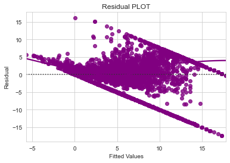

```python
sns.set_style("whitegrid")
sns.residplot(fitted,residual,color="purple",lowess=True)
plt.xlabel("Fitted Values")
plt.ylabel("Residual")
plt.title("Residual PLOT")
plt.show()
```

# TEST FOR NORMALITY

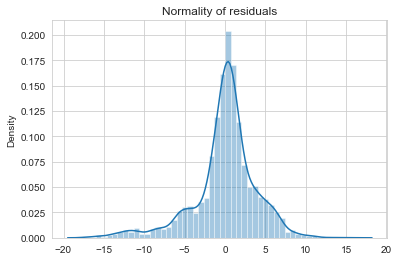

```python
sns.distplot(residual)
plt.title('Normality of residuals')
plt.show()
```

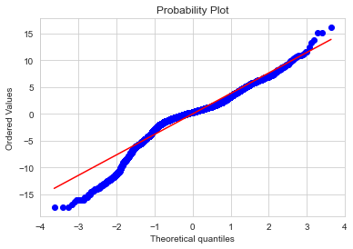

```python
import pylab
import scipy.stats as stats
stats.probplot(residual,dist="norm",plot=pylab)
plt.show()
```

```python
stats.shapiro(residual)
```

```
ShapiroResult(statistic=0.9345179200172424, pvalue=1.3284309441799266e-42)
```

# TEST FOR HOMOSCEDASTICITY

```python
import statsmodels.stats.api as sms
from statsmodels.compat import lzip

name = ['F statistic', 'p-value']
test = sms.het_goldfeldquandt(residual, X_train4)
lzip(name, test)
```

```
[('F statistic', 0.9760875150806069), ('p-value', 0.7287528956898774)]
```

Since p-value > 0.05 so the residuals are homoscedastic. This assumption is therefore valid in the data.

```python
X_train6.columns
```

```
Index(['Year', 'Seats', 'age', 'Power_Float', 'New_Price_Numeric_log'], dtype='object')
```

Our model built by above mentioned.

```python
X_test_final = X_test[X_train6.columns]
```

```python
y_pred = olsres6.predict(X_test_final)
```

# Checking the performance on train and test using RMSE

```python
from sklearn.metrics import mean_squared_error
rms = np.sqrt(mean_squared_error(Y_train, fitted))
print('Train error:',rms)

rms1 = np.sqrt(mean_squared_error(Y_test, y_pred))
print('Test error:',rms1)
```

```
Train error: 3.936142006641899
Test error: 3.8666116468281664
```

we have low test and train error and also both the errors do not have much difference, so our model is not suffering from overfitting.

# linear regression model linear regression model to predict the prices of used cars.

# Insight & Recommendation

1.Company can focus more in improving in the sales of third and above owners type cars.  
2.Company should try to match the sale of the other fuel type cars to diesel variant type cars sales. 3.people prefer a vehicle with lesser age as the age of the vehicle decrease people preference to buy decrease,so company can choose a comparatively latest manufactured car than a old car for resale. 4.As the age of the vehicle increases the mileage decreases,thereby indicating a lesser quality engine. 5.Company can try to increase the sales volume of the luxury cars equivalent to low and middle segment caes.